# Intro to Clinical Research

Madelyn Houser

2/18/2021

```r
# This will load the packages needed for this analysis and document the version of each that I'm using

# If you have not previously installed any of these packages, install them using the function
## install.packages("PACKAGENAME")

# Because a line of code in this Markdown produces HTML content and we want to be able to knit to Word still,
## make sure the following packages are installed on your machine. They do not have to be loaded each time.
# install.packages("webshot")
# webshot::install_phantomjs()

library("Hmisc")
packageVersion("Hmisc")
```

```
## [1] '4.4.1'
```

```r
library("tidyverse")
packageVersion("tidyverse")
```

```
## [1] '1.3.0'
```

```r
library("desctable")
packageVersion("desctable")
```

```
## [1] '0.1.7'
```

```r
library("ggpubr")
packageVersion("ggpubr")
```

```
## [1] '0.4.0'
```

# Import and merge data

```r
# Import the data sets of your choice into R from files saved locally on your computer
# Replace the path here with the path to your local file
demo <- sasxport.get("C:/Users/mecho/Documents/Emory/Post-doc/Presentations/IntroToClinicalResearch_GuestLecture/NHANES/DEMO_J.XPT")
```

```
## Processing SAS dataset DEMO_J     ..
```

```r
cbc <- sasxport.get("C:/Users/mecho/Documents/Emory/Post-doc/Presentations/IntroToClinicalResearch_GuestLecture/NHANES/CBC_J.XPT")
```

```
## Processing SAS dataset CBC_J      ..
```

```r
hepc <- sasxport.get("C:/Users/mecho/Documents/Emory/Post-doc/Presentations/IntroToClinicalResearch_GuestLecture/NHANES/HEPC_J.XPT")
```

```
## Processing SAS dataset HEPC_J     ..
```

```r
# Alternatively, you can download the files from NHANES directly into R
# Replace the URLs with the URLs of the data sets of your choice
download.file("https://wwwn.cdc.gov/Nchs/Nhanes/2017-2018/DEMO_J.XPT", tf <- tempfile(), mode="wb")
demo2 <- foreign::read.xport(tf)

download.file("https://wwwn.cdc.gov/Nchs/Nhanes/2017-2018/CBC_J.XPT", tf <- tempfile(), mode="wb")
cbc2 <- foreign::read.xport(tf)

download.file("https://wwwn.cdc.gov/Nchs/Nhanes/2017-2018/HEPC_J.XPT", tf <- tempfile(), mode="wb")
hepc2 <- foreign::read.xport(tf)
```

```r
# You can remove variables that you don't want to keep in your environment
rm(tf, cbc2, demo2, hepc2)
```

```r
# Select only the variables of interest from the data sets
demo <- demo %>% select(seqn, riagendr, ridageyr, ridagemn)
```

```r
# Merge into one data set, keeping only rows with matching identifiers in demographic data set
df <- merge(x=demo, y=cbc, by="seqn", all.x=TRUE)
df <- merge(x=df, y=hepc, by="seqn", all.x=TRUE)
```

# Explore and Summarize data

```r
# Report class of the data set
class(df)
```

```
## [1] "data.frame"
```

```r
# This will provide some basic information on each variable in the data set
describe(df)
```

```
## df
##
##  28  Variables      9254  Observations
## --------------------------------------------------------------------------------
## seqn : Respondent sequence number
##        n  missing distinct     Info     Mean      Gmd      .05      .10
##     9254        0     9254        1    98330     3085    94166    94628
##      .25      .50      .75      .90      .95
##    96016    98330   100643   102031   102493
##
## lowest :  93703  93704  93705  93706  93707, highest: 102952 102953 102954 102955 102956
## --------------------------------------------------------------------------------
## riagendr : Gender
##        n  missing distinct     Info     Mean      Gmd
##     9254        0        2     0.75    1.508   0.4999
##
## Value          1     2
## Frequency   4557  4697
## Proportion 0.492 0.508
## --------------------------------------------------------------------------------
## ridageyr : Age in years at screening
##        n  missing distinct     Info     Mean      Gmd      .05      .10
##     9254        0       81        1    34.33    29.18        1        3
##      .25      .50      .75      .90      .95
##       11       31       58       71       79
##
## lowest :  0  1  2  3  4, highest: 76 77 78 79 80
## --------------------------------------------------------------------------------
## ridagemn : Age in months at screening - 0 to 24 mos
##        n  missing distinct     Info     Mean      Gmd      .05      .10
##      597     8657       25    0.998    10.44    8.157        0        1
##      .25      .50      .75      .90      .95
##        4       10       17       21       22
##
## lowest :  0  1  2  3  4, highest: 20 21 22 23 24
## --------------------------------------------------------------------------------
## lbxwbcsi : White blood cell count (1000 cells/uL)
##        n  missing distinct     Info     Mean      Gmd      .05      .10
##     7528     1726      149        1    7.383    2.519      4.3      4.8
##      .25      .50      .75      .90      .95
```

[output cut: 201 more lines]

[output not shown]

# Data cleanup and wrangling

Let’s check the format of our variables and label the levels of categorical variables and make sure they’re classified as factors.

```r
# Check class of variable
class(df$riagendr)
```

```
## [1] "labelled" "integer"
```

```r
# Make variable a factor and define levels and labels of levels
df$riagendr <- factor(df$riagendr, levels=c("1", "2"), labels=c("Male", "Female"))
# Change the name of the variable
df <- rename(df, "Sex" = "riagendr")
# Check the class of the variable again to be sure that the changes were made correctly
class(df$Sex)
```

```
## [1] "factor"
```

```r
# Check class and change label of another variable
class(df$ridageyr)
```

```
## [1] "labelled" "integer"
```

```r
label(df$ridageyr) <- "Age (years)"
df <- rename(df, "Age" = "ridageyr")

# Spot check class of lab test variables
class(df$lbxwbcsi)
```

```
## [1] "labelled" "numeric"
```

```r
class(df$lbxlypct)
```

```
## [1] "labelled" "numeric"
```

```r
class(df$lbxnrbc)
```

```
## [1] "labelled" "numeric"
```

```r
# Fix formatting of Hep C RNA variable
class(df$lbxhcr)
```

```
## [1] "labelled" "integer"
```

```r
df$lbxhcr <- factor(df$lbxhcr, levels=(c("1", "2", "3")), labels=c("Positive", "Negative", "Negative Ab Screening"))
df <- rename(df, "HepC_RNA" = "lbxhcr")
class(df$HepC_RNA)
```

```
## [1] "factor"
```

```r
# Check factor levels of the variable
levels(df$HepC_RNA)
```

```
## [1] "Positive"              "Negative"              "Negative Ab Screening"
```

```r
# Rename some other variables
df <- rename(df, "RBCs" = "lbxrbcsi")
df <- rename(df, "Leukocytes" = "lbxwbcsi")
df <- rename(df, "Lymphocytes" = "lbxlypct")
```

Let’s filter the data so that we’re only analyzing data for adults

```r
dfad <- df %>% filter(Age >= 18)

summary(dfad$Age)
```

```
##    Min. 1st Qu.  Median    Mean 3rd Qu.    Max.
##   18.00   33.00   51.00   49.89   65.00   80.00
```

# Visualize data for variables of interest

## Table - Categorical Variables by Sex

```r
# Create a table summarizing some variables of interest by sex
Tab1 <- dfad %>% group_by(Sex) %>% select(Age, HepC_RNA) %>% desctable() %>% datatable()
```

```
## * N -> N...1
## * Median -> Median...3
## * IQR -> IQR...4
## * N -> N...5
## * ...
```

```
## * N -> N...2
## * Median -> Median...4
## * IQR -> IQR...5
## * N -> N...6
## * ...
```

```r
Tab1
```

[interactive table not shown]

## Variable graphs

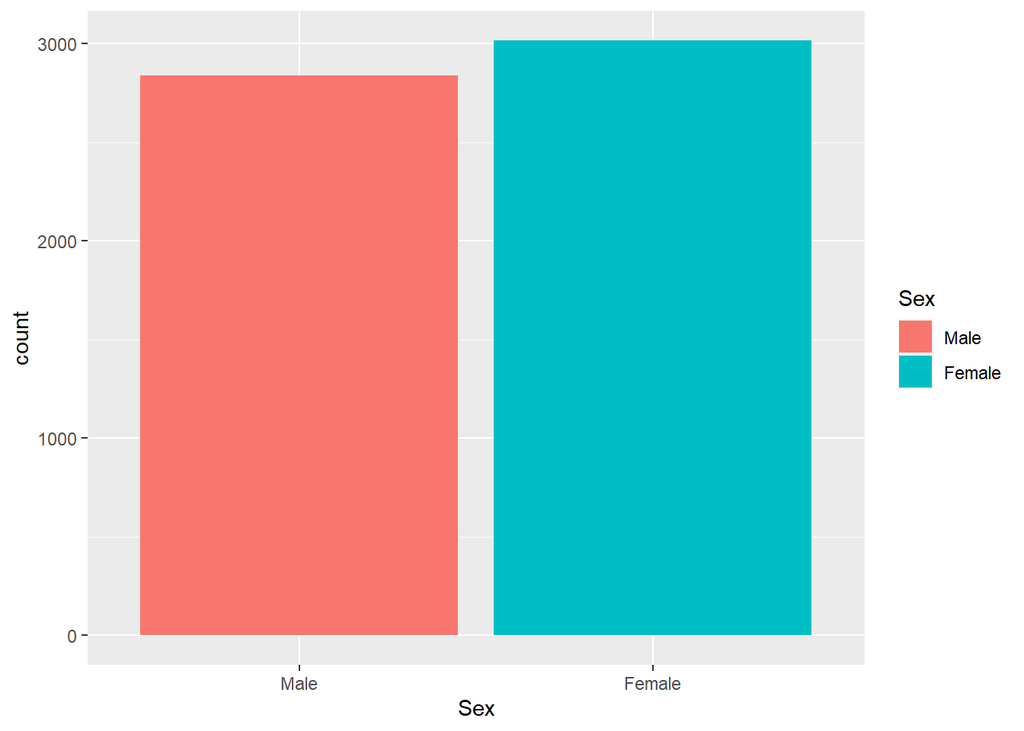

```r
# Plot counts of each level of a categorical variable
ggplot(data = dfad) +
  geom_bar(mapping = (aes(x = Sex, fill=Sex)))
```

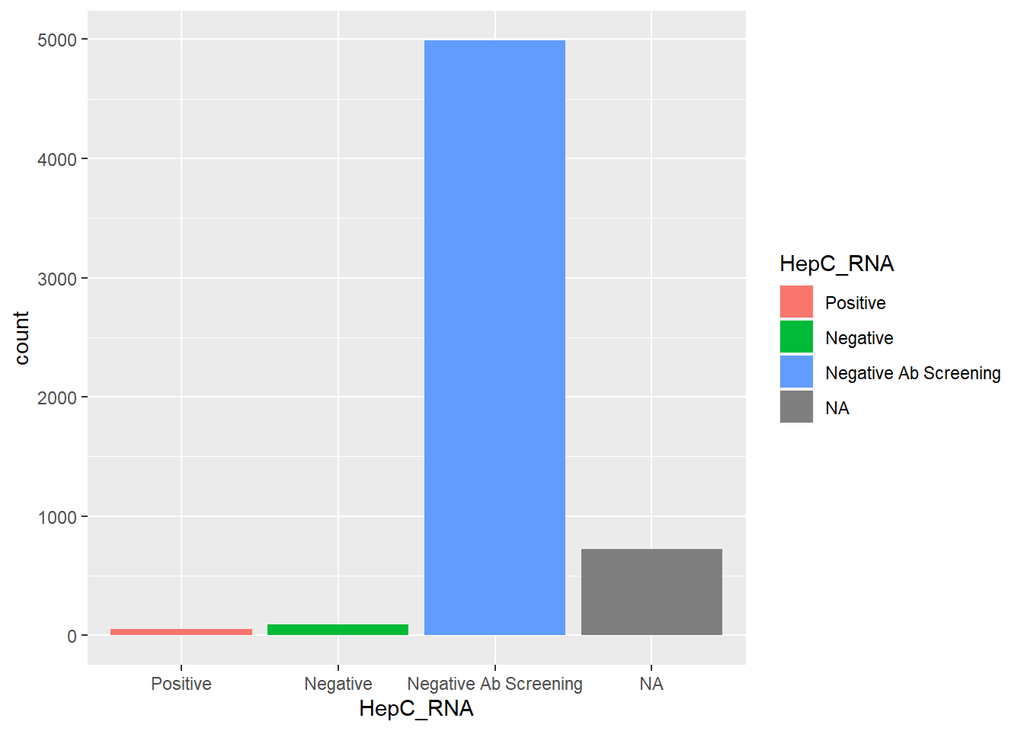

```r
ggplot(data = dfad) +
  geom_bar(mapping = (aes(x = HepC_RNA, fill=HepC_RNA)))
```

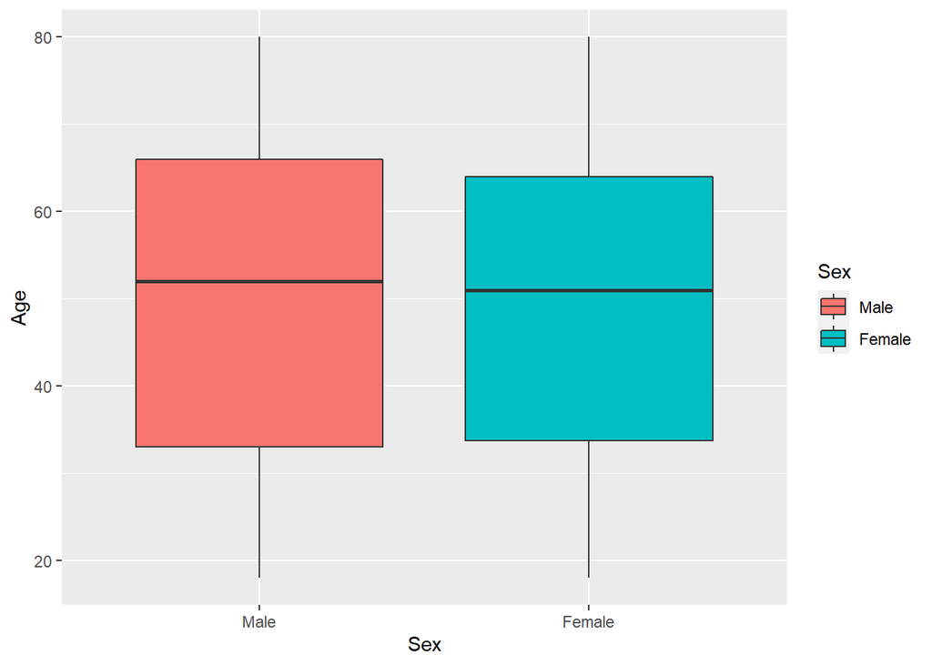

```r
# Plot Age split by Sex
ggplot(data = dfad) +
  geom_boxplot(mapping=aes(x=Sex, y=Age, fill=Sex))
```

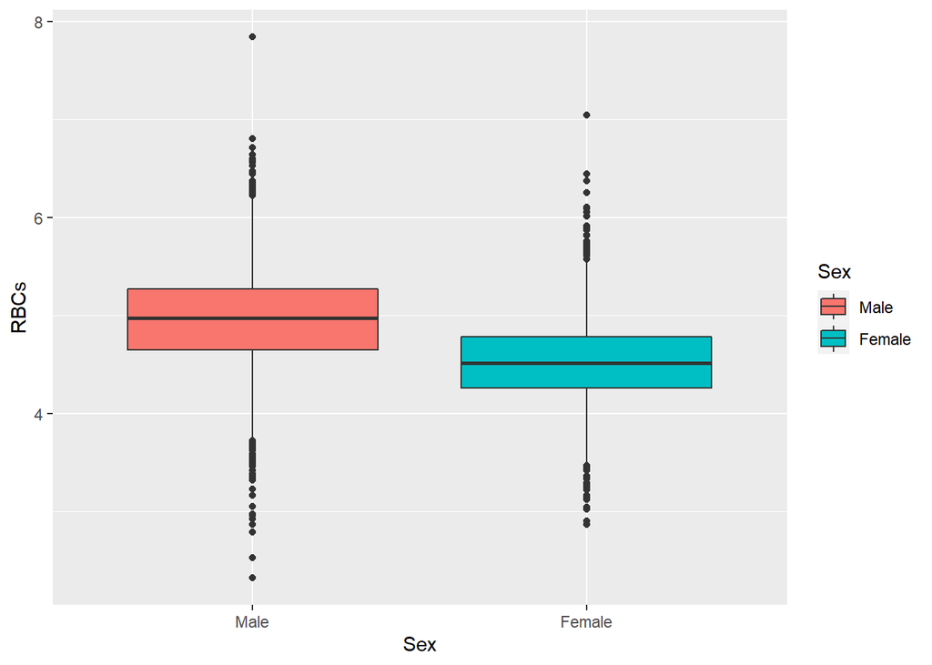

```r
# Create a boxplot of RBCs data split by Sex
ggplot(data=dfad, mapping=aes(x=Sex, y=RBCs, fill=Sex)) +
  geom_boxplot()
```

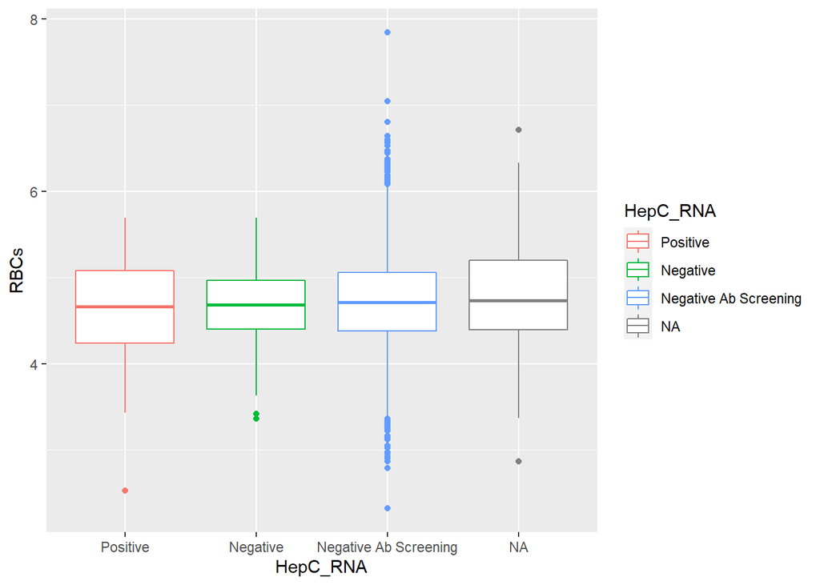

```r
# Create a boxplot of RBCs data split by HepC_RNA
ggplot(data=dfad, mapping=aes(x=HepC_RNA, y=RBCs, color=HepC_RNA)) +
  geom_boxplot()
```

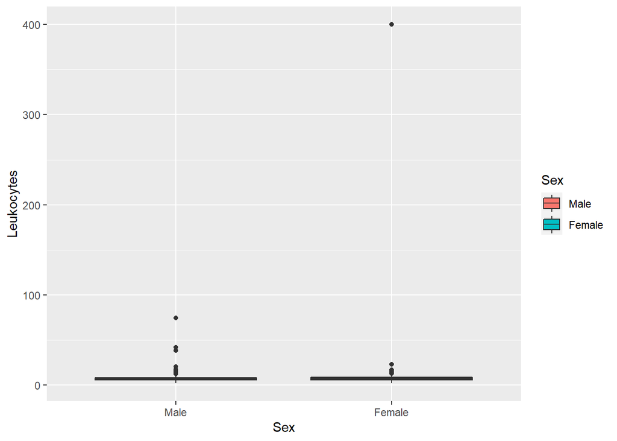

```r
# Repeat with other continuous variables
ggplot(data=dfad, mapping=aes(x=Sex, y=Leukocytes, fill=Sex)) +
  geom_boxplot()
```

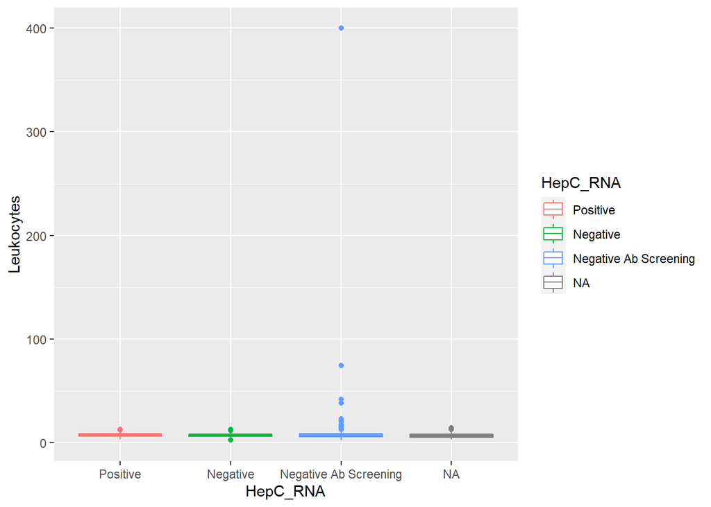

```r
ggplot(data=dfad, mapping=aes(x=HepC_RNA, y=Leukocytes, color=HepC_RNA)) +
  geom_boxplot()
```

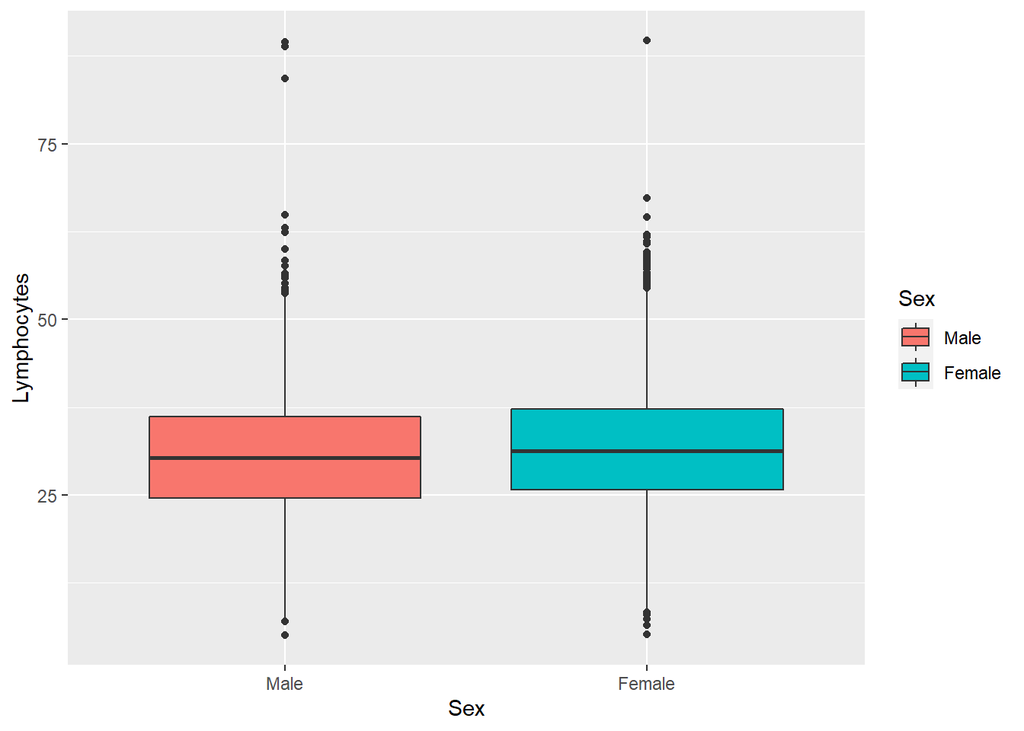

```r
ggplot(data=dfad, mapping=aes(x=Sex, y=Lymphocytes, fill=Sex)) +
  geom_boxplot()
```

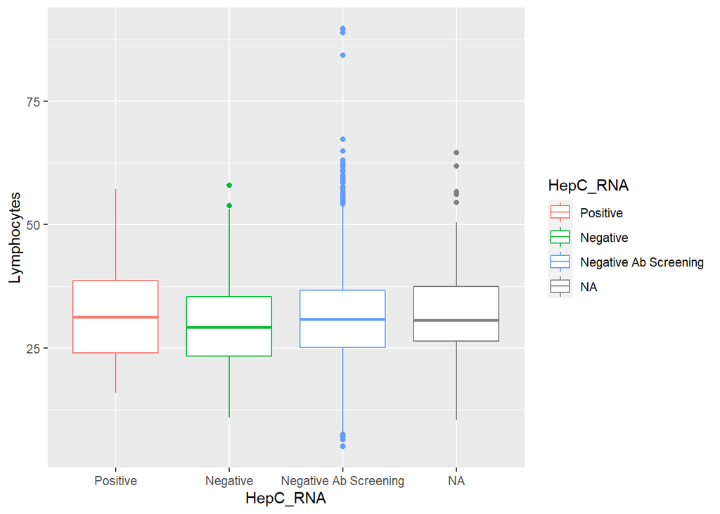

```r
ggplot(data=dfad, mapping=aes(x=HepC_RNA, y=Lymphocytes, color=HepC_RNA)) +
  geom_boxplot()
```

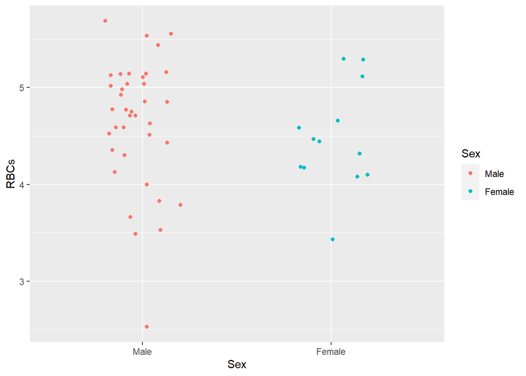

```r
# Let's make sure we have enough data to work with within our HepC positive group if we split it by sex

# Create a data set with only subjects positive for HepC RNA
dfadpos <- dfad %>% filter(HepC_RNA == "Positive")

ggplot(data=dfadpos, mapping=aes(x=Sex, y=RBCs, color=Sex)) +
  geom_jitter(width=.2)
```

#### We observe that there is an extremely high value in the Leukocytes variable data.

## Check distribution of continuous variables

### Density and Q-Q plots

Let’s plot the distribution of some continuous variables.

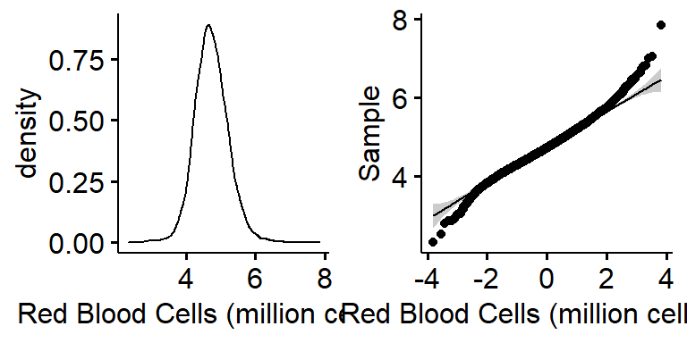

```r
# Create an object consisting of a plot of the distribution of the RBCs variable
denplot <- ggdensity(df$RBCs, xlab = "Red Blood Cells (million cells/uL)")
# Create an object consisting of a Q-Q plot of the RBCs variable
qqplot <- ggqqplot(df$RBCs, xlab = "Red Blood Cells (million cells/uL)")
# Show the plots side by side
ggarrange(denplot, qqplot, ncol=2, nrow=1)
```

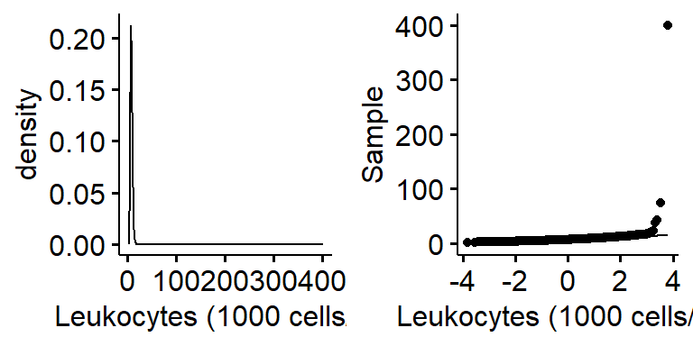

```r
# Repeat for the next variable of interest
denplot <- ggdensity(df$Leukocytes, xlab = "Leukocytes (1000 cells/uL)")
qqplot <- ggqqplot(df$Leukocytes, xlab = "Leukocytes (1000 cells/uL)")

ggarrange(denplot, qqplot, ncol=2, nrow=1)
```

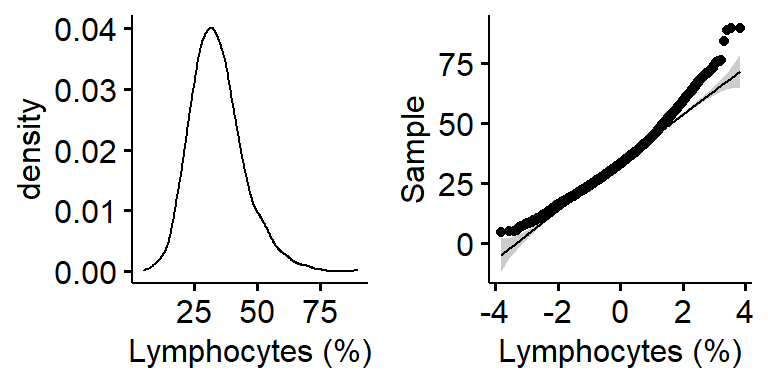

```r
# Repeat for the next variable of interest
denplot <- ggdensity(df$Lymphocytes, xlab = "Lymphocytes (%)")
qqplot <- ggqqplot(df$Lymphocytes, xlab = "Lymphocytes (%)")

ggarrange(denplot, qqplot, ncol=2, nrow=1)
```

# Remove outlier

There is one extremely high value in the Leukocytes variable data that is not at all comparable to the other values. Let’s exclude that subject from our analysis.

```r
# Return the value in column 1 that has the maximum value in the Leukocytes column in the dfad data set
# This relies on indexing, which means referring to a specific position in the dataset
# In R, indexing takes the format: data[row#, column#]
print(dfad[which.max(dfad$Leukocytes),1])
```

```
## Respondent sequence number
## [1] 102389
```

```r
# Remove the row with the outlier (keep all data that do not match the selected ID number in the seqn column)
dfad <- dfad %>% filter(seqn != "102389")
```

# Is there a sex difference in Hepatitis C RNA positivity?

Let’s run a chi-square test to address this question.

```r
# Chi-square test
stats::chisq.test(x=dfad$Sex, y=dfad$HepC_RNA)
```

```
##
##  Pearson's Chi-squared test
##
## data:  dfad$Sex and dfad$HepC_RNA
## X-squared = 15.071, df = 2, p-value = 0.0005338
```

```r
# Let's focus on just the positives and negatives in people who got an RNA test
# Let's also just drop the NAs in the HepC_RNA column to simplify graphing
dfadHepC <- dfad %>% drop_na(HepC_RNA) %>% filter(HepC_RNA != "Negative Ab Screening")

# Run the Chi-square test on just the RNA test subjects
stats::chisq.test(x=dfadHepC$Sex, y=dfadHepC$HepC_RNA)
```

```
##
##  Pearson's Chi-squared test with Yates' continuity correction
##
## data:  dfadHepC$Sex and dfadHepC$HepC_RNA
## X-squared = 5.9286, df = 1, p-value = 0.0149
```

Let’s make a graph to visualize this comparison.

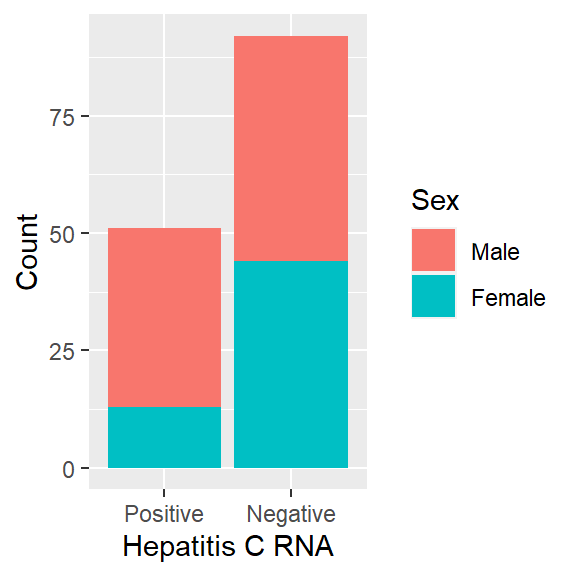

```r
ggplot(data=dfadHepC, mapping=aes(x=HepC_RNA, fill=Sex)) +
  geom_bar() +
  xlab("Hepatitis C RNA") +
  ylab("Count")
```

```r
# Save this plot
ggsave("C:/Users/mecho/Documents/Emory/Post-doc/Presentations/IntroToClinicalResearch_GuestLecture/HepCRNA_by_Sex.pdf")
```

### Results: HepC RNA positivity by sex

#### Positivity in an RNA test for hepatitis C does differ significantly by sex. Males are more likely than females to test positive for hepatitis C RNA.

# Do leukocyte counts differ in subjects who test positive for hepatitis C from those that test negative?

Let’s run a one-way ANOVA to address this question.

```r
# One-way ANOVA
res <- aov(Leukocytes ~ HepC_RNA, dfad)
summary(res)
```

```
##               Df Sum Sq Mean Sq F value Pr(>F)
## HepC_RNA       2      3   1.287   0.218  0.804
## Residuals   5125  30246   5.902
## 727 observations deleted due to missingness
```

Let’s make a graph to visualize this comparison.

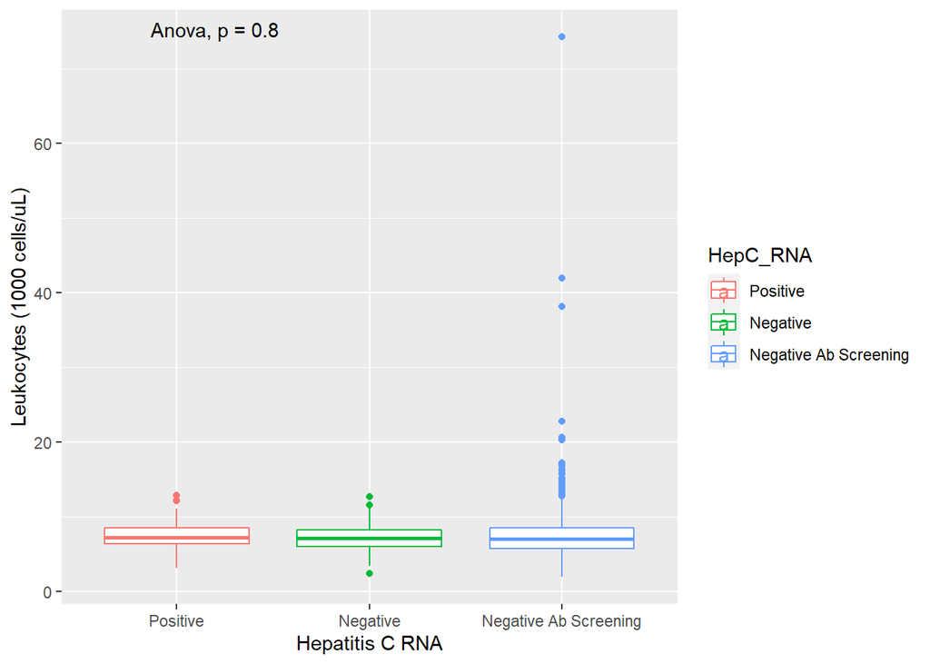

```r
# Remove NAs in HepC_RNA variable for graphing purposes
dfadHepC2 <- dfad %>% drop_na(HepC_RNA)

ggplot(data=dfadHepC2, mapping=aes(x=HepC_RNA, y=Leukocytes, color=HepC_RNA)) +
  geom_boxplot() +
  xlab("Hepatitis C RNA") +
  ylab("Leukocytes (1000 cells/uL)") +
  stat_compare_means(method="aov")
```

```r
ggsave("C:/Users/mecho/Documents/Emory/Post-doc/Presentations/IntroToClinicalResearch_GuestLecture/Leukocytes_by_HepCRNA.pdf")
```

### Results: Leukocyte concentrations by HepC RNA result

#### Leukocyte concentrations do not differ significantly based on hepatitis C RNA positivity status.

# Do lymphocyte and RBC levels correlate with one another?

Let’s do a Pearson correlation to address this question.

```r
# Pearson correlation
cor.test(x=dfad$Lymphocytes, y=dfad$RBCs, method="pearson")
```

```
##
##  Pearson's product-moment correlation
##
## data:  dfad$Lymphocytes and dfad$RBCs
## t = 0.4836, df = 5264, p-value = 0.6287
## alternative hypothesis: true correlation is not equal to 0
## 95 percent confidence interval:
##  -0.02034841  0.03366933
## sample estimates:
##         cor
## 0.006665322
```

Let’s make a graph to visualize this comparison.

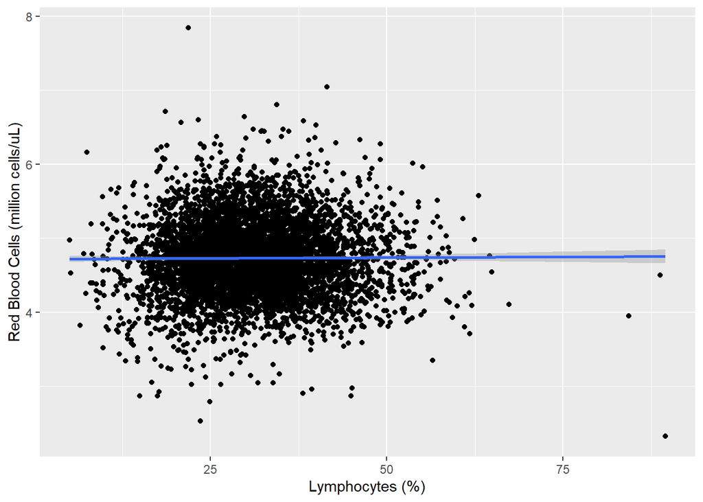

```r
ggplot(data=dfad, mapping=aes(x=Lymphocytes, y=RBCs)) +
  geom_point() +
  xlab("Lymphocytes (%)") +
  ylab("Red Blood Cells (million cells/uL)") +
  geom_smooth(method="lm")
```

```r
  stat_cor(method="pearson")
```

```
## geom_text: parse = TRUE, na.rm = FALSE
## stat_cor: label.x.npc = left, label.y.npc = top, label.x = NULL, label.y = NULL, label.sep = , , method = pearson, alternative = two.sided, output.type = expression, digits = 2, r.digits = 2, p.digits = 2, r.accuracy = NULL, p.accuracy = NULL, cor.coef.name = R, na.rm = FALSE
## position_identity
```

```r
ggsave("C:/Users/mecho/Documents/Emory/Post-doc/Presentations/IntroToClinicalResearch_GuestLecture/Lymphocytes_by_RBCs.pdf")
```

### Results: Lymphocyte and RBC concentrations

#### Lymphocyte and RBC concentrations are not correlated with one another.